# Tesla stock data from 2010 to 2020

## How did TSLA do since its inception?

Dataset from https://www.kaggle.com/timoboz/tesla-stock-data-from-2010-to-2020

```python
# import necessary libraries
import pandas as pd
import numpy as np
import matplotlib.pyplot as plt
import seaborn as sns
import plotly
```

```python
%matplotlib inline
```

### 1. Loading the Dataset

```python
tesla = pd.read_csv('tesla_stock_data.csv')
```

#### Data Description

- Date - Date of trading
- Open - Opening price of the stock on that particular day
- High - Highest trading price on the day
- Low - Lowest trading price on the day
- Adj Close - Adjusted closing price, taking splits etc into account
- Volume - Number of trades on that day

### 2. Some pre-processing before we move on to the fun part

```python
# See the first 5 rows of the data
tesla.head()
```

|  | Date | Open | High | Low | Close | Adj Close | Volume |
| --- | --- | --- | --- | --- | --- | --- | --- |
| 0 | 2010-06-29 | 19.000000 | 25.00 | 17.540001 | 23.889999 | 23.889999 | 18766300 |
| 1 | 2010-06-30 | 25.790001 | 30.42 | 23.299999 | 23.830000 | 23.830000 | 17187100 |
| 2 | 2010-07-01 | 25.000000 | 25.92 | 20.270000 | 21.959999 | 21.959999 | 8218800 |
| 3 | 2010-07-02 | 23.000000 | 23.10 | 18.709999 | 19.200001 | 19.200001 | 5139800 |
| 4 | 2010-07-06 | 20.000000 | 20.00 | 15.830000 | 16.110001 | 16.110001 | 6866900 |

```python
# See the last 5 rows of the data
tesla.tail()
```

|  | Date | Open | High | Low | Close | Adj Close | Volume |
| --- | --- | --- | --- | --- | --- | --- | --- |
| 2411 | 2020-01-28 | 568.489990 | 576.809998 | 558.080017 | 566.900024 | 566.900024 | 11788500 |
| 2412 | 2020-01-29 | 575.690002 | 589.799988 | 567.429993 | 580.989990 | 580.989990 | 17801500 |
| 2413 | 2020-01-30 | 632.419983 | 650.880005 | 618.000000 | 640.809998 | 640.809998 | 29005700 |
| 2414 | 2020-01-31 | 640.000000 | 653.000000 | 632.520020 | 650.570007 | 650.570007 | 15719300 |
| 2415 | 2020-02-03 | 673.690002 | 786.140015 | 673.520020 | 780.000000 | 780.000000 | 47065000 |

```python
tesla.shape
```

```
(2416, 7)
```

The dataset has 2416 observations and 7 features from 2010-06-29 to 2020-02-03.

```python
tesla.dtypes
```

```
Date          object
Open         float64
High         float64
Low          float64
Close        float64
Adj Close    float64
Volume         int64
dtype: object
```

```python
# checking null values
tesla.isnull().sum()
```

```
Date         0
Open         0
High         0
Low          0
Close        0
Adj Close    0
Volume       0
dtype: int64
```

Here, we can infer from the above cell that the dataset contains no null values and therefore we don't need to impute any missing values.

```python
# converting Date feature to datetime feature
tesla.Date = pd.to_datetime(tesla.Date)
tesla.dtypes
```

```
Date         datetime64[ns]
Open                float64
High                float64
Low                 float64
Close               float64
Adj Close           float64
Volume                int64
dtype: object
```

## 3. Exploratory Data Analysis

#### 3.1 - Trend Analysis

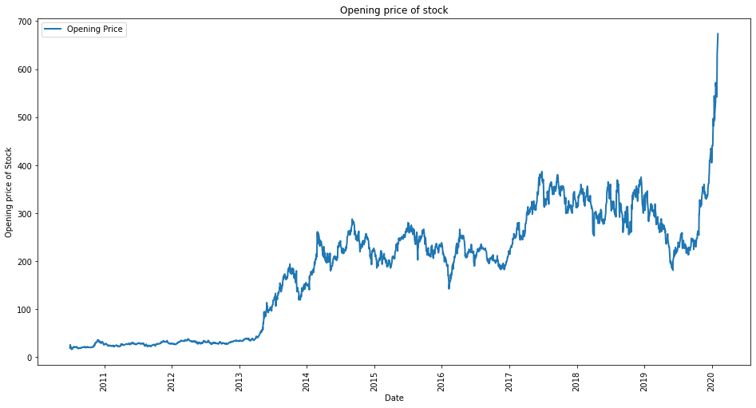

```python
# Date vs opening price
plt.figure(figsize=(16, 8))
plt.plot(tesla.Date, tesla.Open, lw=2, label='Opening Price')
plt.title('Opening price of stock')
plt.xlabel('Date')
plt.ylabel('Opening price of Stock')
plt.xticks(rotation=90)
plt.legend()
plt.show()
```

Tesla's stock price from 2010 to the Q1 of 2013 were mostly stationary but after 2013 the stock price has mostly increased and it reached its peak in 2020. During 2011 and 2012, their revenues were around $ 30-$40 million per quarter. Then in the last quarter of 2012 they exploded and reached USD 306 million, and went to USD 560 million in the first quarter of 2013. So that’s almost a 20-fold increase in revenues in a very short period of time. Even though Wall Street was very bullish on the stock back then, even they didn’t anticipate such demand for their cars. The stock price responded promptly and went from USD 40 in April to USD 190 by September 2013.

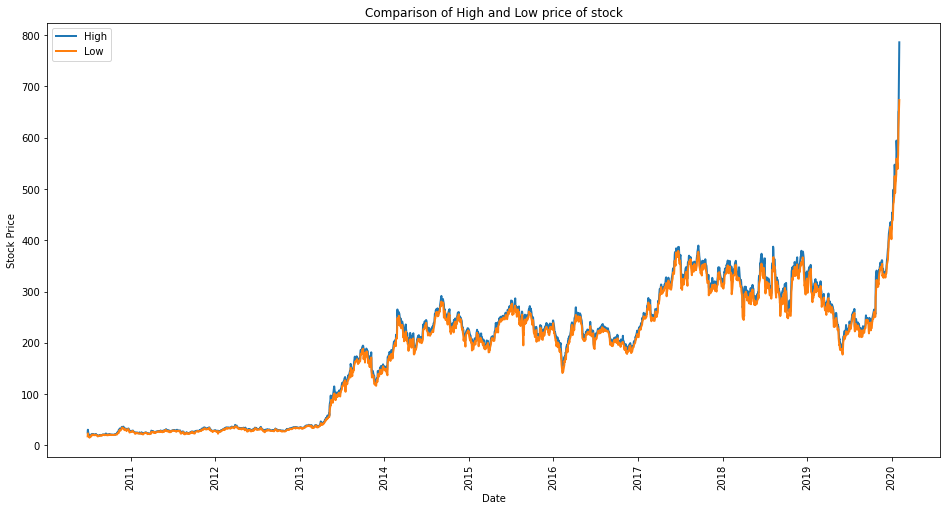

```python
# comparing highest and lowest trading price
plt.figure(figsize=(16, 8))
plt.plot(tesla.Date, tesla.High, lw=2, label='High')
plt.plot(tesla.Date, tesla.Low, lw=2, label='Low')
plt.title('Comparison of High and Low price of stock')
plt.xlabel('Date')
plt.ylabel('Stock Price')
plt.xticks(rotation=90)
plt.legend()
plt.show()
```

The lowest and highest trading prices are rather close to each other for this data and we can see that this trend continues through the data.

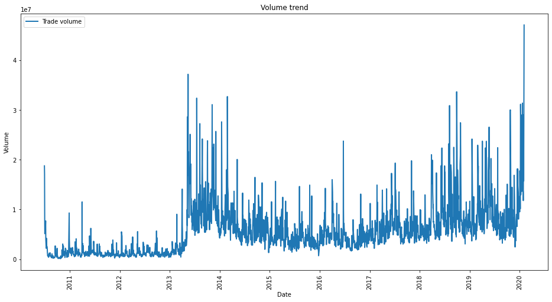

```python
# Analyzing Volume of trades
plt.figure(figsize=(16, 8))
plt.plot(tesla.Date, tesla.Volume, lw=2, label='Trade volume')
plt.title('Volume trend')
plt.xlabel('Date')
plt.ylabel('Volume')
plt.xticks(rotation=90)
plt.legend()
plt.show()
```

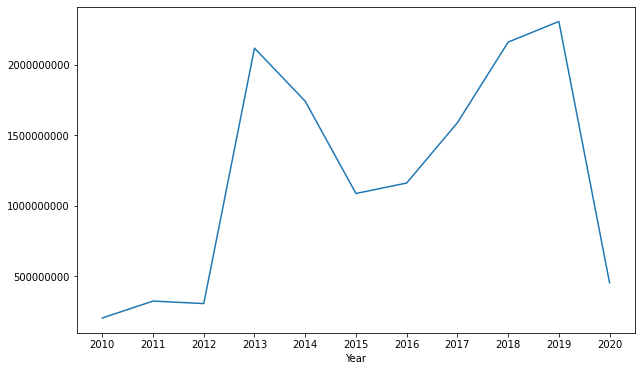

```python
tesla['Year'] = tesla['Date'].dt.year
volume = pd.DataFrame(tesla.groupby('Year').sum()['Volume'])

plt.figure(figsize=(10,6))
plt.plot(volume)
plt.xlabel('Year')
plt.xticks(volume.index)
plt.ticklabel_format(style='plain')
```

```python
# checking number of sales
volume.sort_values(by='Volume', ascending=False)
```

| Year | Volume |
| --- | --- |
| 2019 | 2308042000 |
| 2018 | 2161638800 |
| 2013 | 2118745900 |
| 2014 | 1742321300 |
| 2017 | 1590031400 |
| 2016 | 1162361700 |
| 2015 | 1088217800 |
| 2020 | 454283500 |
| 2011 | 325235100 |
| 2012 | 307449000 |
| 2010 | 205369100 |

```
          Volume
Date
5     1309223600
10    1286663400
1     1243700900
6     1205766600
8     1166461300
7     1163162500
11    1111010200
4     1071875300
12    1015574600
9      967704800
2      967475600
3      955076800
```

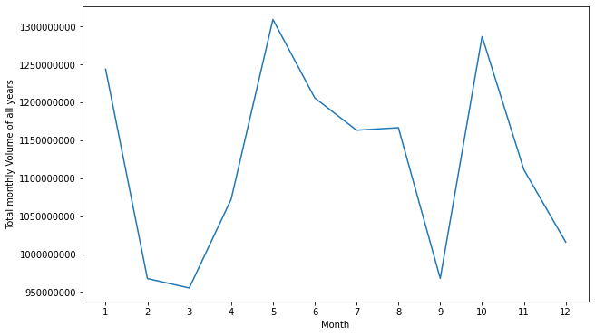

```python
# Looking at monthly volumes
by_month = pd.DataFrame(tesla.groupby(tesla['Date'].dt.month).sum()['Volume'])
print(by_month.sort_values(by='Volume', ascending=False))
plt.figure(figsize=(10, 6))
plt.plot(by_month)
plt.xticks(by_month.index)
plt.xlabel('Month')
plt.ylabel('Total monthly Volume of all years')
plt.ticklabel_format(style='plain')
```

So, we get the insight that May is the month where most of the trades happened. (For reasons I don't know)

```python
# The mean opening and Closing price every year for the stock
mean_price = pd.DataFrame(tesla.groupby('Year').mean()[['Open', 'Close']])
```

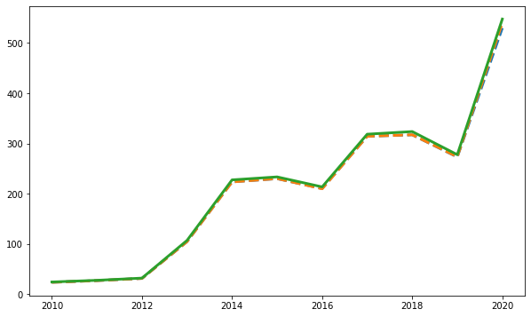

```python
plt.figure(figsize=(10, 6))
plt.plot(mean_price, lw=3, ls='--')
plt.plot(tesla.groupby('Year').mean()['High'], lw=3)
```

The value of Tesla stock prices has also gone up significantly.

#### 3.2 - Creating Columns (Daily Return)

We will create the daily lag column to help us calculate the daily returns in % for the stock prices after the sales close for the day before.

```python
tesla['daily_lag'] = tesla['Close'].shift(1)
tesla.head()
```

|  | Date | Open | High | Low | Close | Adj Close | Volume | Year | daily_lag |
| --- | --- | --- | --- | --- | --- | --- | --- | --- | --- |
| 0 | 2010-06-29 | 19.000000 | 25.00 | 17.540001 | 23.889999 | 23.889999 | 18766300 | 2010 | NaN |
| 1 | 2010-06-30 | 25.790001 | 30.42 | 23.299999 | 23.830000 | 23.830000 | 17187100 | 2010 | 23.889999 |
| 2 | 2010-07-01 | 25.000000 | 25.92 | 20.270000 | 21.959999 | 21.959999 | 8218800 | 2010 | 23.830000 |
| 3 | 2010-07-02 | 23.000000 | 23.10 | 18.709999 | 19.200001 | 19.200001 | 5139800 | 2010 | 21.959999 |
| 4 | 2010-07-06 | 20.000000 | 20.00 | 15.830000 | 16.110001 | 16.110001 | 6866900 | 2010 | 19.200001 |

```python
tesla['daily_returns'] = (tesla['daily_lag'] / tesla['Close']) - 1
tesla.head()
```

|  | Date | Open | High | Low | Close | Adj Close | Volume | Year | daily_lag | daily_returns |
| --- | --- | --- | --- | --- | --- | --- | --- | --- | --- | --- |
| 0 | 2010-06-29 | 19.000000 | 25.00 | 17.540001 | 23.889999 | 23.889999 | 18766300 | 2010 | NaN | NaN |
| 1 | 2010-06-30 | 25.790001 | 30.42 | 23.299999 | 23.830000 | 23.830000 | 17187100 | 2010 | 23.889999 | 0.002518 |
| 2 | 2010-07-01 | 25.000000 | 25.92 | 20.270000 | 21.959999 | 21.959999 | 8218800 | 2010 | 23.830000 | 0.085155 |
| 3 | 2010-07-02 | 23.000000 | 23.10 | 18.709999 | 19.200001 | 19.200001 | 5139800 | 2010 | 21.959999 | 0.143750 |
| 4 | 2010-07-06 | 20.000000 | 20.00 | 15.830000 | 16.110001 | 16.110001 | 6866900 | 2010 | 19.200001 | 0.191806 |

```python
mean = tesla['daily_returns'].mean()
std = tesla['daily_returns'].std()
print("Mean % returns: {:.4f}".format(mean))
print("Std of % returns: {:.2f}".format(std))
```

```
Mean % returns: -0.0009
Std of % returns: 0.03
```

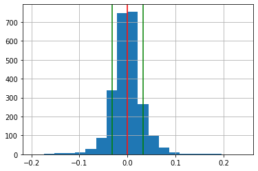

```python
tesla['daily_returns'].hist(bins=20)
plt.axvline(mean, color='red')
plt.axvline(std, color='green')
plt.axvline(-std, color='green')
```

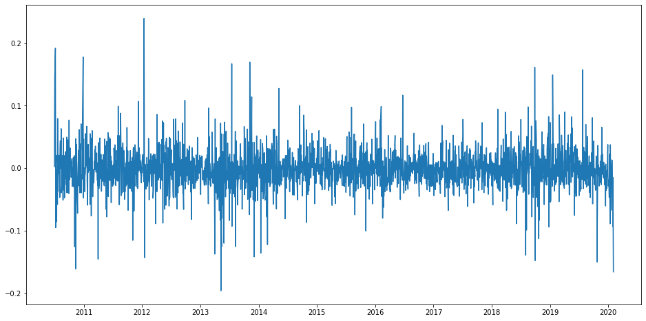

```python
plt.figure(figsize=(16,8))
plt.plot(tesla.Date, tesla.daily_returns)
```

### 3.3 - Interactive Plots (plotly)

```python
# Setting up plotly
import cufflinks as cf
import plotly.express as px
import plotly.graph_objects as go
from plotly.offline import download_plotlyjs, init_notebook_mode, plot, iplot
init_notebook_mode(connected=True)
cf.go_offline()
```

```python
fig = px.line(tesla, x='Date', y='Open', title='Date v/s Open price w/o Slider')
fig.show()
```

[interactive chart not shown]

```python
# Date vs Opening Price
fig = px.line(tesla, x='Date', y='Open', title='Date v/s Open price with Slider')
fig.update_xaxes(rangeslider_visible=True)
fig.show()
```

[interactive chart not shown]

```python
# Date and Volume
fig = px.line(tesla, x='Date', y='Volume', title='Date v/s Volume w/o Slider')
fig.show()
```

[interactive chart not shown]

```python
# Date and Daily Returns
fig = px.line(tesla, x='Date', y='daily_returns', title='Date v/s Volume w/o Slider')
fig.show()
```

[interactive chart not shown]